# Using tree based methods to detect customer churn and customer calue for an Iranian call centre

Bhavana Kappala

2025-04-16

## Objective

The objective of this project is to apply the CART (Classification and Regression Trees) method and Random Forest to predict customer value based on continuous features and to develop a binary prediction model for customer churn. The goal is to identify key factors influencing customer behavior, optimize decision-making processes, and provide actionable insights for customer retention strategies.

## Introduction

### Description of Data:

The dataset consists of customer information and various attributes that can be used to analyze customer behavior, predict churn, and assess customer value. The variables included are:

**Call Failures**: The total number of call failures experienced by a customer, which could indicate issues with the service or network.

**Complains**: A binary variable indicating whether the customer has lodged a complaint. `0` means no complaint, and `1` means the customer has made a complaint.

**Subscription Length**: The total duration (in months) of the customer’s subscription. This feature may give insights into customer loyalty and engagement.

**Seconds of Use**: The total number of seconds the customer has spent on calls. This continuous variable helps assess the intensity of customer use.

**Frequency of Use**: The total number of calls made by the customer. This variable quantifies how frequently a customer uses the service.

**Frequency of SMS**: The total number of SMS messages sent by the customer, which can reflect communication behavior and engagement with the service.

**Distinct Called Numbers**: The total number of unique phone numbers called by the customer, providing insight into their calling patterns.

**Age Group**: An ordinal attribute representing the customer’s age group, where `1` indicates a younger age and `5` represents an older age. This can be useful in understanding how customer demographics influence behavior.

**Tariff Plan**: A binary variable indicating the customer’s tariff plan. `1` represents “Pay as you go” and `2` indicates a “Contractual” plan.

**Status**: A binary variable that indicates whether the customer is active (`1`) or non-active (`2`). This feature can be used to assess customer engagement or identify churn.

**Churn**: The class label for churn prediction, where `1` indicates a customer who has churned (discontinued the service), and `0` means a non-churn customer.

**Customer Value**: A calculated value representing the overall worth of the customer based on their behavior, subscription, and usage patterns. This value can be used for segmentation and targeting.

This dataset includes both continuous and binary features, providing a mix of information on customer behavior, usage patterns, and attributes that can be utilized to predict customer churn and assess customer value.

## Relationship between Features

**Correlation Plot**

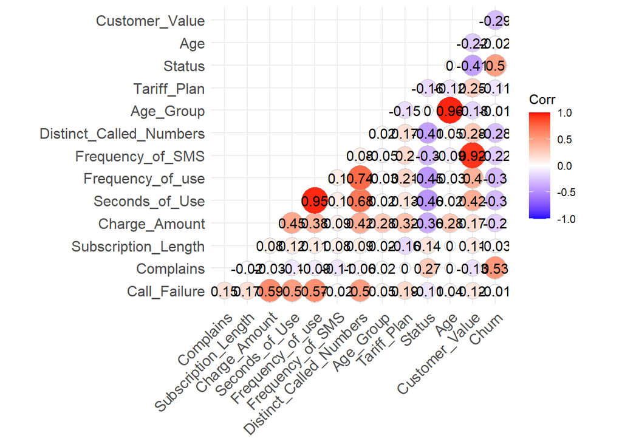

```r
df_num <- df
#df_num$Churn <- as.numeric(as.factor(df_num$Churn))
numeric_features <- df_num %>% select_if(is.numeric)
# Compute correlation matrix
cor_matrix <- cor(numeric_features, use = "complete.obs")

# Plot heatmap
ggcorrplot(cor_matrix, method = "circle", type = "lower", lab = TRUE)
```

## Relationship between Features

**Relationship between highly correlated numerical features using Scatter Plot**

The scatter plot shows a clear positive relationship between the number of SMS messages sent and Customer Value. As SMS frequency increases, customer value tends to rise, though the data points form distinct bands, possibly indicating customer segmentation or pricing plans. This trend suggests SMS usage is a strong predictor of customer value and can be valuable for churn or value-based modeling.

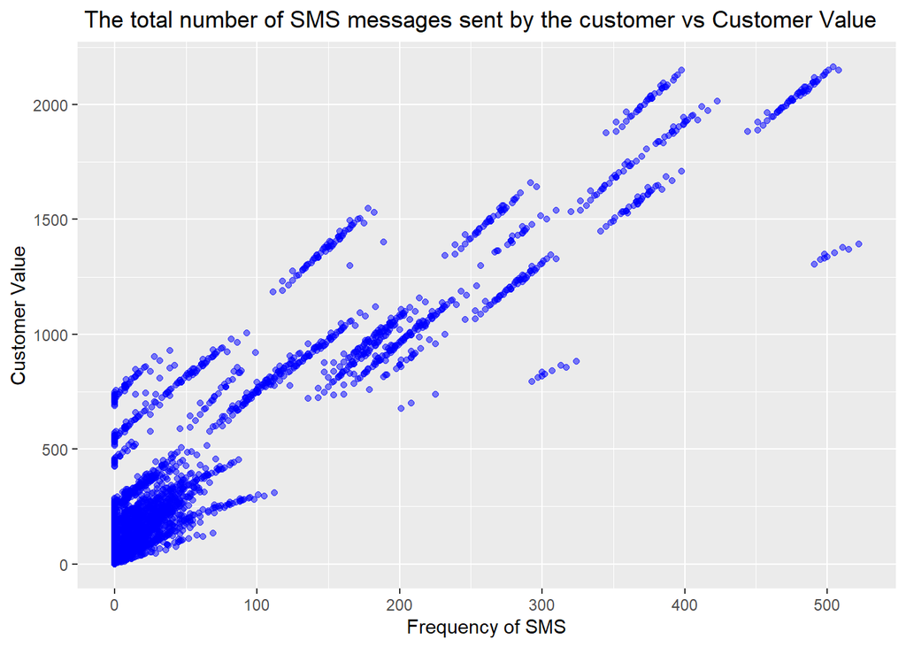

```r
# Scatter plot using ggplot2
ggplot(df, aes(x=Frequency_of_SMS, y=Customer_Value)) +
  geom_point(color="blue", alpha=0.5) +
  ggtitle(" The total number of SMS messages sent by the customer vs Customer Value ") +
  xlab(" Frequency of SMS ") +
  ylab("Customer Value")
```

**Relationship between Target Variable and a categorical feature using heatmap**

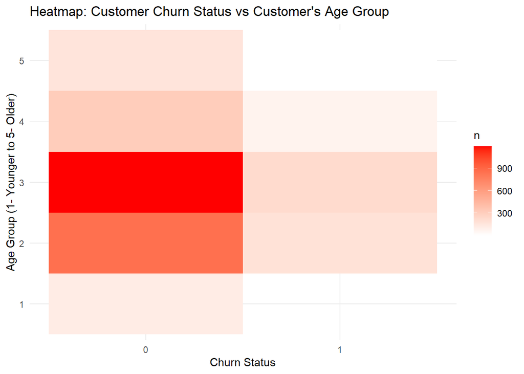

```r
df$Churn <- as.factor(df$Churn)
df$Age_Group <- as.factor(df$Age_Group)

heatmap_data <- df %>%
  count(Churn, Age_Group)

ggplot(heatmap_data, aes(x = Churn, y = Age_Group , fill = n)) +
  geom_tile() +
  labs(title = "Heatmap: Customer Churn Status vs Customer's Age Group ",
       x = "Churn Status", y = "Age Group (1- Younger to 5- Older)") +
  scale_fill_gradient(low = "white", high = "red") +
  theme_minimal()
```

**Box Plot**

The boxplot shows that customers who did not churn tend to have significantly higher customer value compared to those who churned, indicating a negative relationship between customer value and churn likelihood.

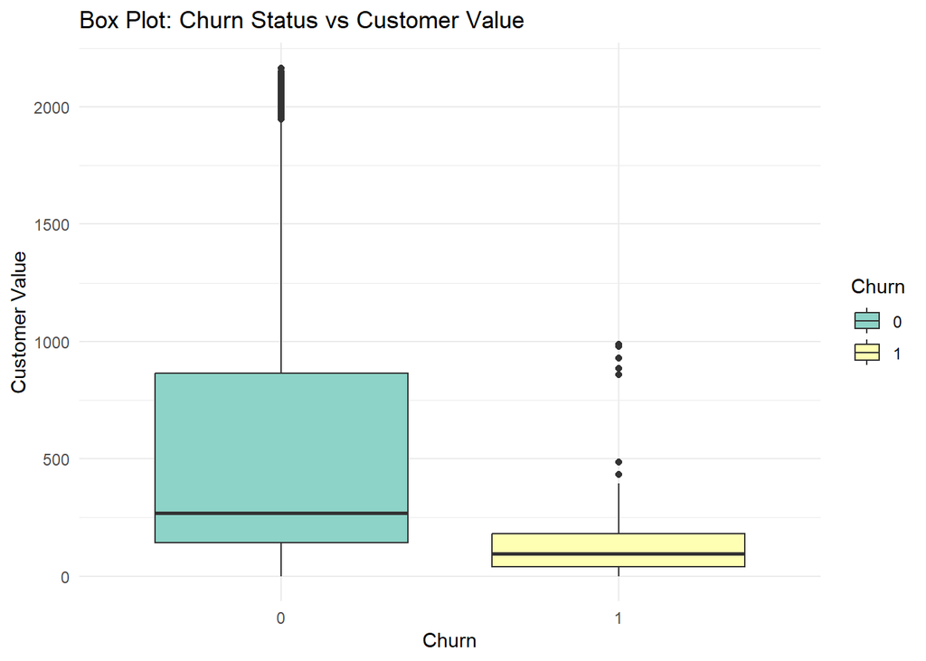

```r
# Box Plot: Relationship between Churn Status (Categorical) and  Customer Value (Numerical)
ggplot(df, aes(x = Churn, y = Customer_Value, fill = Churn)) +
  geom_boxplot() +
  labs(title = "Box Plot: Churn Status vs Customer Value",
       x = " Churn ", y = "Customer Value") +
  theme_minimal() +
  scale_fill_brewer(palette = "Set3")
```

## Skewness

Most of these variables are right-skewed, with a majority of values concentrated in lower ranges and a small number of extreme values. These skewed distributions may need transformation for better model performance.

```r
#str(df)

df$Charge_Amount <- as.factor(df$Charge_Amount)
df$Age_Group <- as.factor(df$Age_Group)
df$Tariff_Plan <- as.factor(df$Tariff_Plan)
df$Status <- as.factor(df$Status)
df$Churn <- as.factor(df$Churn)

# Select only numeric columns
numeric_vars <- df[, sapply(df, is.numeric)]
# Compute skewness for each numeric variable
skewness_values <- sapply(numeric_vars, skewness, na.rm = TRUE)

# Identify highly skewed variables
skewed_vars <- names(skewness_values[abs(skewness_values) > 1])

# Print results
#print("Skewness values:")
#print(skewness_values)
print("Highly skewed variables:")
```

```
[1] "Highly skewed variables:"
```

```r
print(skewed_vars)
```

```
[1] "Call_Failure"            "Complains"
[3] "Subscription_Length"     "Seconds_of_Use"
[5] "Frequency_of_use"        "Frequency_of_SMS"
[7] "Distinct_Called_Numbers" "Age"
[9] "Customer_Value"
```

```r
# Create a histogram for Skewed Numeric Variable - No of Credit Accounts
#hist(numeric_vars$No_of_credit_acc, main = "Histogram of No of Credit Accounts", xlab = "No of Credit Accounts",      col = "lightblue",      breaks = 30)
```

## Feature Engineering

**Transformation, Normalization & Standardization**

```r
df$Call_Failure = as.numeric(df$Call_Failure)
df$Subscription_Length = as.numeric(df$Subscription_Length)
df$Age = as.numeric(df$Age)
df$Seconds_of_Use = as.numeric(df$Seconds_of_Use)
df$Frequency_of_use = as.numeric(df$Frequency_of_use)
df$Frequency_of_SMS = as.numeric(df$Frequency_of_SMS)
df$Distinct_Called_Numbers = as.numeric(df$Distinct_Called_Numbers)
df$Customer_Value = as.numeric(df$Customer_Value)
df$Complains = as.numeric(df$Complains)

#str(df)

df_trans <- df %>%
  mutate(
    Call_Failure_trans = log1p(Call_Failure),
    Subscription_Length_trans = log1p(Subscription_Length),
    Age_trans = log1p(Age),
    Seconds_of_Use_trans = log1p(Seconds_of_Use),
    Frequency_of_use_trans = log1p(Frequency_of_use),
    Frequency_of_SMS_trans = log1p(Frequency_of_SMS),
    Distinct_Called_Numbers_trans = log1p(Distinct_Called_Numbers),
    Customer_Value_trans = log1p(Customer_Value),
    Complains_trans = log1p(Complains)
  )



# Normalization
normalize <- function(x) {
  return((x - min(x)) / (max(x) - min(x)))
}

df_norm <- df_trans

df_norm$Call_Failure_trans_norm = normalize(df_norm$Call_Failure_trans)
df_norm$Subscription_Length_trans_norm = normalize(df_norm$Subscription_Length_trans)
df_norm$Age_trans_norm = normalize(df_norm$Age_trans)
df_norm$Seconds_of_Use_trans_norm = normalize(df_norm$Seconds_of_Use_trans)
df_norm$Frequency_of_use_trans_norm = normalize(df_norm$Frequency_of_use_trans)
df_norm$Frequency_of_SMS_trans_norm = normalize(df_norm$Frequency_of_SMS_trans)
df_norm$Distinct_Called_Numbers_trans_norm = normalize(df_norm$Distinct_Called_Numbers_trans)
df_norm$Customer_Value_trans_norm = normalize(df_norm$Customer_Value_trans)
df_norm$Complains_trans_norm = normalize(df_norm$Complains_trans)


# Custom Standardization function
standardize <- function(x) {
  if (is.numeric(x)) {
    return((x - mean(x)) / sd(x))  # Standardize only numeric columns
  } else {
    return(x)  # If the column is not numeric, return it as is
  }
}

# Create a copy for standardized data
df_stan <- df_norm


df_stan$Call_Failure_stan = standardize(df_stan$Call_Failure_trans)
df_stan$Subscription_Length_stan = standardize(df_stan$Subscription_Length_trans)
df_stan$Age_stan = standardize(df_stan$Age_trans)
df_stan$Seconds_of_Use_stan = standardize(df_stan$Seconds_of_Use_trans)
df_stan$Frequency_of_use_stan = standardize(df_stan$Frequency_of_use_trans)
df_stan$Frequency_of_SMS_stan = standardize(df_stan$Frequency_of_SMS_trans)
df_stan$Distinct_Called_Numbers_stan = standardize(df_stan$Distinct_Called_Numbers_trans)
df_stan$Customer_Value_stan = standardize(df_stan$Customer_Value_trans)
df_stan$Complains_stan = standardize(df_stan$Complains_trans)


# View structure
#str(df_stan)
```

## Principal Component Analysis

Based on the results of Principal Component Analysis (PCA), it appears that using the first few principal components (PCs) can be beneficial for dimensionality reduction. The first few components (PC1 to PC5) account for a significant proportion of the variance, with PC1 alone explaining 20.34% and the first five PCs cumulatively explaining about 47.87%. As we move to later components, the proportion of variance explained decreases rapidly, with PCs beyond PC10 contributing very little.

```r
#str(df_pca)

df_pca <- df_stan %>%
  select(Call_Failure_stan,
         Subscription_Length_stan,
         Age_stan,
         Seconds_of_Use_stan,
         Frequency_of_use_stan,
         Frequency_of_SMS_stan,
         Distinct_Called_Numbers_stan,
         Customer_Value_stan,
         Complains_stan,
         Charge_Amount,
         Age_Group,
         Tariff_Plan,
        Status,
        Churn)

#dummies <- dummyVars(~ ., data = df_pca)
#numeric_data <- predict(dummies, newdata = df_pca) %>% as.data.frame()


#str(df_numeric)

# Step 1: Convert categorical variables to numeric using one-hot encoding
df_numeric <- df_pca %>%
 mutate(across(c(Age_Group,
         Tariff_Plan,
        Status,
        Churn), as.factor)) %>%  # Convert to factors
   dummyVars(~ ., data = .) %>%
  predict(newdata = df_pca) %>%
   as.data.frame()

 # Step 2: Select only numeric features
 numeric_data <- df_numeric %>% select_if(is.numeric)

 # Step 3: Handle missing and infinite values
 numeric_data[is.na(numeric_data)] <- 0   # Replace NAs with 0 (or use median imputation)



constant_cols <- apply(numeric_data, 2, function(col) var(col, na.rm = TRUE) == 0)
numeric_data <- numeric_data[, !constant_cols]


# Step 4: Standardize the data (only after handling missing values)
 scaled_data <- scale(numeric_data)

 # Step 5: Perform PCA
 pca_result <- prcomp(scaled_data, center = TRUE, scale = TRUE)

 summary(pca_result)
```

```
Importance of components:
                          PC1     PC2    PC3     PC4     PC5     PC6     PC7
Standard deviation     2.5111 1.58977 1.5258 1.45532 1.24937 1.21326 1.15802
Proportion of Variance 0.2034 0.08153 0.0751 0.06832 0.05035 0.04748 0.04326
Cumulative Proportion  0.2034 0.28493 0.3600 0.42836 0.47871 0.52619 0.56945
                           PC8     PC9    PC10    PC11    PC12    PC13    PC14
Standard deviation     1.13593 1.07451 1.05610 1.03024 1.00967 1.00364 1.00183
Proportion of Variance 0.04162 0.03724 0.03598 0.03424 0.03289 0.03249 0.03238
Cumulative Proportion  0.61107 0.64832 0.68430 0.71854 0.75142 0.78391 0.81629
                          PC15    PC16    PC17    PC18    PC19   PC20    PC21
Standard deviation     1.00172 0.96895 0.93366 0.80620 0.79237 0.7407 0.71976
Proportion of Variance 0.03237 0.03029 0.02812 0.02097 0.02025 0.0177 0.01671
Cumulative Proportion  0.84866 0.87895 0.90707 0.92803 0.94829 0.9660 0.98270
                          PC22    PC23    PC24    PC25      PC26      PC27
Standard deviation     0.54080 0.40585 0.21773 0.17831 2.879e-15 2.414e-15
Proportion of Variance 0.00943 0.00531 0.00153 0.00103 0.000e+00 0.000e+00
Cumulative Proportion  0.99213 0.99745 0.99897 1.00000 1.000e+00 1.000e+00
                            PC28      PC29      PC30      PC31
Standard deviation     1.676e-15 5.971e-16 4.547e-16 1.741e-16
Proportion of Variance 0.000e+00 0.000e+00 0.000e+00 0.000e+00
Cumulative Proportion  1.000e+00 1.000e+00 1.000e+00 1.000e+00
```

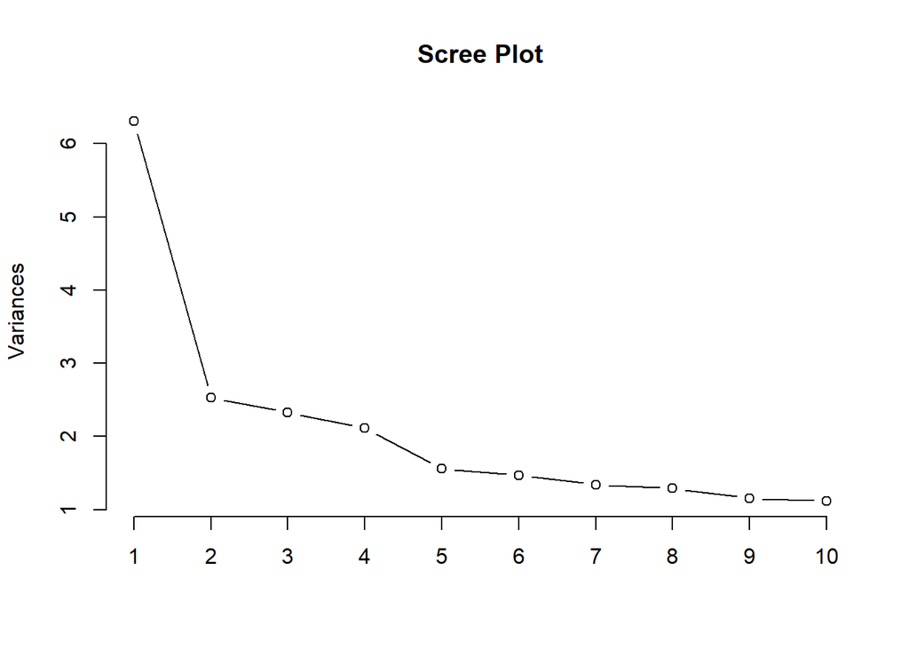

```r
 # Step 6: Scree Plot (to decide number of components to keep)
 screeplot(pca_result, type = "lines", main = "Scree Plot")
```

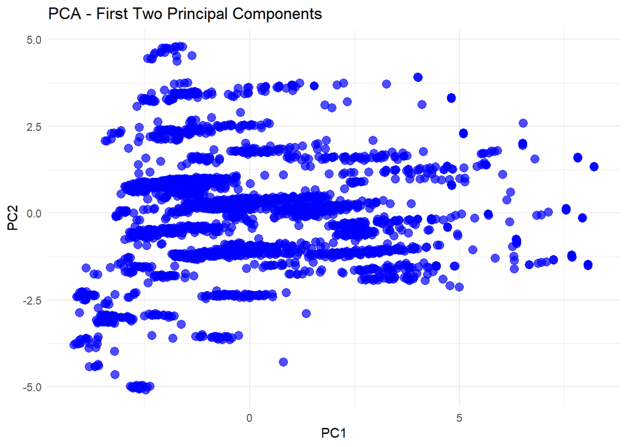

```r
 # Step 7: Biplot (PCA visualization)
# biplot(pca_result, scale = 0)

 # Step 8: Scatter plot of first two principal components
 pca_df <- as.data.frame(pca_result$x)
 ggplot(pca_df, aes(x = PC1, y = PC2)) +
   geom_point(size = 3, alpha = 0.7, color = "blue") +
 labs(title = "PCA - First Two Principal Components") +
   theme_minimal()
```

## CART Based Algorithms

### CART: Classification

*Grow and initial tree*

```r
# Load necessary libraries
# library(rpart)        # For decision trees
# library(rpart.plot)   # For visualizing trees
# library(caret)        # For model evaluation
# library(pROC)         # For ROC analysis

#str(callcenter.data)

# Load the dataset
callcenter.data <- df_stan %>%
  select(Call_Failure_stan,
         Subscription_Length_stan,
         Age_stan,
         Seconds_of_Use_stan,
         Frequency_of_use_stan,
         Frequency_of_SMS_stan,
         Distinct_Called_Numbers_stan,
         Customer_Value_stan,
         Complains_stan,
         Charge_Amount,
         Age_Group,
         Tariff_Plan,
        Status,
        Churn)

# Split data into training (70%) and test (30%) sets
set.seed(123)
train.index <- createDataPartition(callcenter.data$Churn, p = 0.7, list = FALSE)
train.data <- callcenter.data[train.index, ]
test.data <- callcenter.data[-train.index, ]

# Build the initial classification tree
tree.model <- rpart(Churn ~ .,
                    data = train.data,
                    method = "class",   # classification tree
                    parms = list(split = "gini",  # Using Gini index
                                 # FN cost = 1, FP cost = 0.5
                                 loss = matrix(c(0, 0.5, 1, 0), nrow = 2)
                                 ),
                    control = rpart.control(minsplit = 15,  # Min 15 obs to split
                                           minbucket = 5,   # Min 7 obs in leaf
                                           # Complexity parameter
                                           cp = 0.001, # complex parameter
                                           maxdepth = 5))   # Max tree depth

#table(callcenter.data$Churn)
```

```r
rpart.plot(tree.model,
           extra = 104, # check the help document for more information
           # color palette is a sequential color scheme that blends green (G) to blue (Bu)
           box.palette = "GnBu",
           branch.lty = 1,
           shadow.col = "gray",
           nn = TRUE)
```

[output not shown]

```r
# Print the complexity parameter table
pander(tree.model$cptable)
```

| CP | nsplit | rel error | xerror | xstd |
| --- | --- | --- | --- | --- |
| 0.2507 | 0 | 1 | 2 | 0.09856 |
| 0.08646 | 1 | 0.7493 | 1.274 | 0.07994 |
| 0.01945 | 2 | 0.6628 | 1.233 | 0.0795 |
| 0.01873 | 11 | 0.487 | 1.061 | 0.07362 |
| 0.001 | 13 | 0.4496 | 0.928 | 0.0691 |

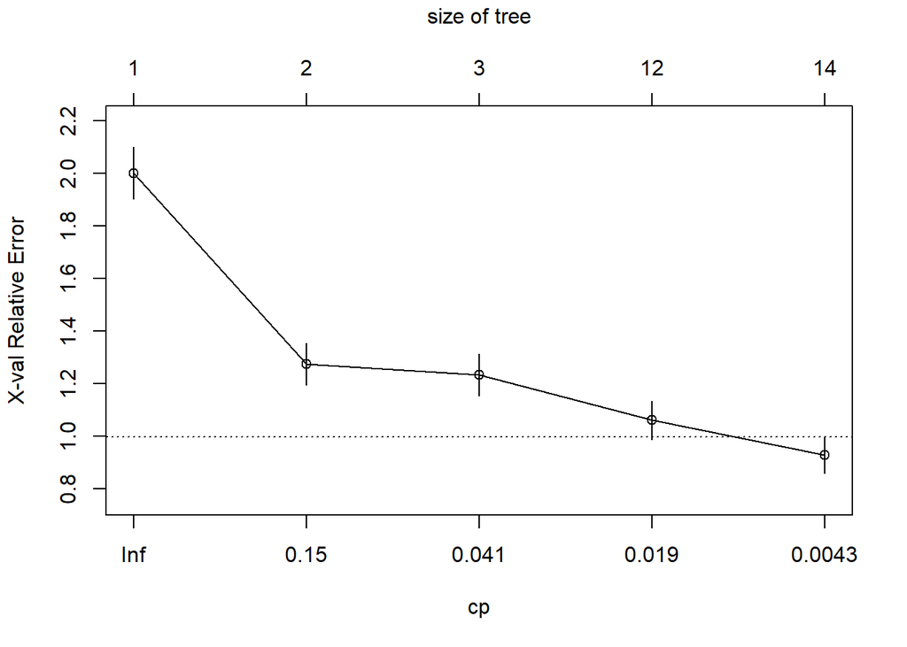

```r
# Plot the cross-validation results
plotcp(tree.model)
```

```r
# Get the minimum cross-validation error and its corresponding cp
min.cp <- tree.model$cptable[which.min(tree.model$cptable[, "xerror"]), "CP"]

# Prune the tree using the optimal cp
pruned.tree.1SE <- prune(tree.model, cp = 0.017)
pruned.tree.min <- prune(tree.model, cp = min.cp)




# Visualize the pruned tree
rpart.plot(pruned.tree.1SE,
           extra = 104, # check the help document for more information
           # color palette is a sequential color scheme that blends green (G) to blue (Bu)
           box.palette = "GnBu",
           branch.lty = 1,
           shadow.col = "gray",
           nn = TRUE)
```

[output not shown]

```r
# Visualize the pruned tree
rpart.plot(pruned.tree.min,
           extra = 104, # check the help document for more information
           # color palette is a sequential color scheme that blends green (G) to blue (Bu)
           box.palette = "GnBu",
           branch.lty = 1,
           shadow.col = "gray",
           nn = TRUE)
```

[output not shown]

**Optimal Cut-off Probability:**

This plot shows the relationship between different probability cutoff values and the resulting misclassification cost. The goal is to find the cutoff that minimizes this cost. The optimal cutoff identified is 0.1667, which corresponds to the lowest misclassification cost on the graph (around 2000 units). At very low or high cutoffs, the cost spikes significantly, indicating poor classification performance. Thus, using a cutoff of 0.1667 helps balance false positives and false negatives in a cost-effective way, which is especially useful in imbalanced classification problems like churn prediction.

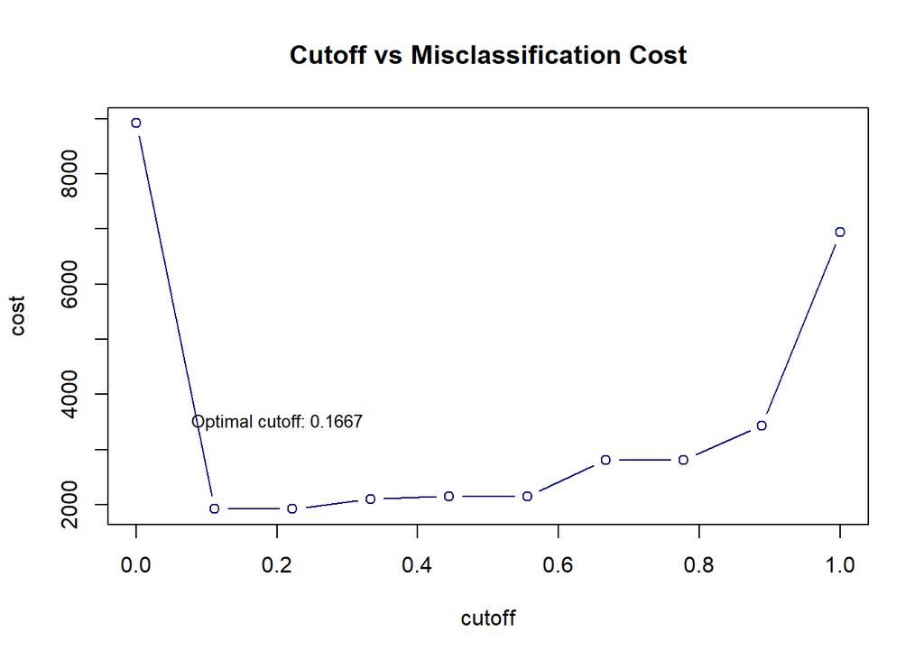

```r
# Predictive probabilities of pruned tree model
pred.prob.min <- predict(pruned.tree.min, train.data, type = "prob")[,2]

# Initialize cost variable
cost <- NULL
cutoff <- seq(0, 1, length = 10)

# Loop through different cutoff values
for (i in 1:10) {
  # Classify based on the cutoff
  pred.label <- ifelse(pred.prob.min > cutoff[i], "1", "0")  # Use "1" for pos and "0" for neg

  # Calculate FN (False Negatives) and FP (False Positives)
  FN <- sum(pred.label == "0" & train.data$Churn == "1")  # False negatives (Churn = 1, predicted as 0)
  FP <- sum(pred.label == "1" & train.data$Churn == "0")  # False positives (Churn = 0, predicted as 1)

  # Calculate the cost (5*FP + 20*FN)
  cost[i] = 5*FP + 20*FN
}

# Identify optimal cutoff that minimizes the cost
min.ID <- which(cost == min(cost))   # Could have multiple minimum values
optim.prob <- mean(cutoff[min.ID])   # Take the average of the cutoff values

# Plot cutoff vs misclassification cost
plot(cutoff, cost, type = "b", col = "navy", main = "Cutoff vs Misclassification Cost")
text(0.2, 3500, paste("Optimal cutoff:", round(optim.prob, 4)), cex = 0.8)
```

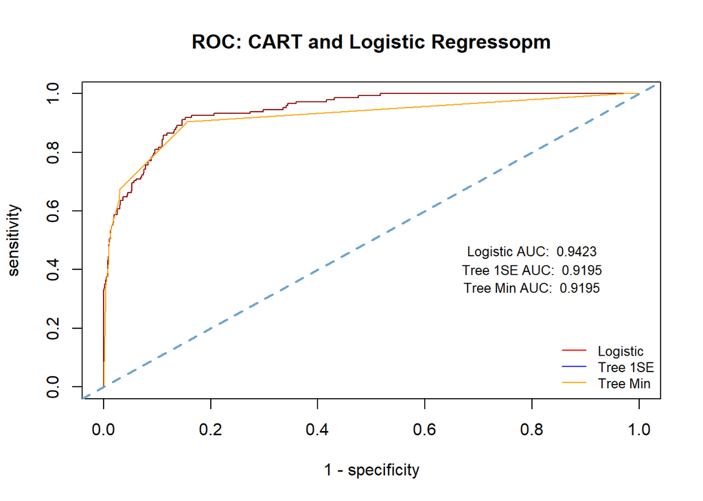

```r
# Make predictions on the test set
pred.label.1SE <- predict(pruned.tree.1SE, test.data, type = "class") # default cutoff 0.5
pred.prob.1SE <- predict(pruned.tree.1SE, test.data, type = "prob")[,2]
##
pred.label.min <- predict(pruned.tree.min, test.data, type = "class") # default cutoff 0.5
pred.prob.min <- predict(pruned.tree.min, test.data, type = "prob")[,2]

# Confusion matrix
#conf.matrix <- confusionMatrix(pred.label, test.data$diabetes, positive = "pos")
#print(conf.matrix)

########################
###  logistic regression
logit.fit <- glm(Churn ~ ., data = train.data, family = binomial)
AIC.logit <- step(logit.fit, direction = "both", trace = 0)
pred.logit <- predict(AIC.logit, test.data, type = "response")

# ROC curve and AUC
roc.tree.1SE <- roc(test.data$Churn, pred.prob.1SE)
roc.tree.min <- roc(test.data$Churn, pred.prob.min)
roc.logit <- roc(test.data$Churn, pred.logit)

##
### Sen-Spe
tree.1SE.sen <- roc.tree.1SE$sensitivities
tree.1SE.spe <- roc.tree.1SE$specificities
#
tree.min.sen <- roc.tree.min$sensitivities
tree.min.spe <- roc.tree.min$specificities
#
logit.sen <- roc.logit$sensitivities
logit.spe <- roc.logit$specificities
## AUC
auc.tree.1SE <- roc.tree.1SE$auc
auc.tree.min <- roc.tree.min$auc
auc.logit <- roc.logit$auc
###
plot(1-logit.spe, logit.sen,
     xlab = "1 - specificity",
     ylab = "sensitivity",
     col = "darkred",
     type = "l",
     lty = 1,
     lwd = 1,
     main = "ROC: CART and Logistic Regressopm")
lines(1-tree.1SE.spe, tree.1SE.sen,
      col = "blue",
      lty = 1,
      lwd = 1)
lines(1-tree.min.spe, tree.min.sen,
      col = "orange",
      lty = 1,
      lwd = 1)
abline(0,1, col = "skyblue3", lty = 2, lwd = 2)
legend("bottomright", c("Logistic", "Tree 1SE", "Tree Min"),
       lty = c(1,1,1), lwd = rep(1,3),
       col = c("red", "blue", "orange"),
       bty="n",cex = 0.8)
## annotation - AUC
text(0.8, 0.46, paste("Logistic AUC: ", round(auc.logit,4)), cex = 0.8)
text(0.8, 0.4, paste("Tree 1SE AUC: ", round(auc.tree.1SE,4)), cex = 0.8)
text(0.8, 0.34, paste("Tree Min AUC: ", round(auc.tree.min,4)), cex = 0.8)
```

### CART: Regression

CART regression analysis helps identify the optimal model complexity for accurately estimating how valuable a customer is likely to be—such as in terms of purchase behavior, lifetime value, or profitability.

The chart and output show that as the model allows for more decision splits (i.e., becomes more complex), the prediction error initially decreases substantially, meaning the model is better at distinguishing between high- and low-value customers. However, beyond about 20 splits, additional complexity doesn’t significantly improve predictive accuracy. This suggests that a tree of this size captures the most meaningful patterns in the data (e.g., purchase history, engagement levels, demographics) without overfitting.

Therefore, the analysis indicates that a moderately complex decision tree (around 20 splits) is sufficient to reliably predict customer value. This balance helps businesses segment customers effectively and make data-driven decisions about marketing, retention, and resource allocation—focusing efforts on customers with the highest predicted value while avoiding unnecessary complexity that could reduce generalizability to new customers.

**1. Tree Induction, 2. Splitting Criteria & 3. Stopping rule: min observations to split**

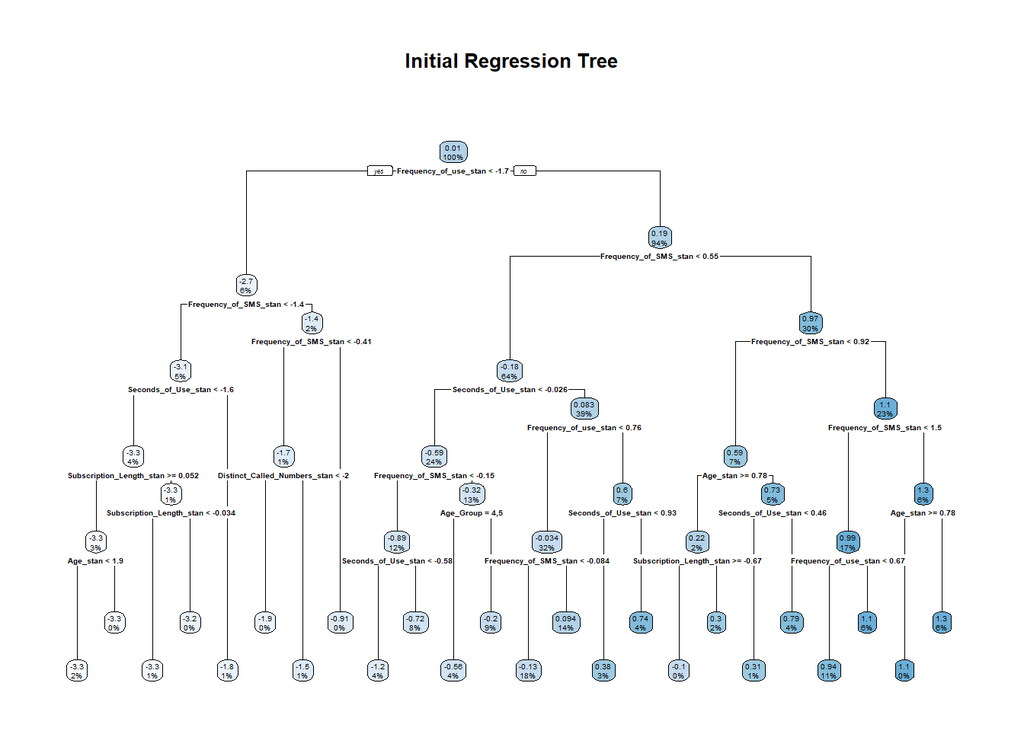

```r
# Load required packages and data
#library(rpart)          # For regression trees
#library(rpart.plot)     # For visualizing trees

# Set seed for reproducibility
set.seed(123)

# Split data into training (70%) and test (30%) sets
train.index <- sample(1:nrow(callcenter.data), size = 0.7 * nrow(callcenter.data))
train.data <- callcenter.data[train.index, ]
test.data <- callcenter.data[-train.index, ]

# Build the initial regression tree using rpart
tree.model <- rpart(Customer_Value_stan ~ .,
                    data = train.data,
                    method = "anova",     # For regression
                    control = rpart.control(
                      minsplit = 20,    # 3. Stopping rule: min observations to split
                      minbucket = 7,    # Min observations in terminal node
                      cp = seq(0, 0.05, 20), # Complexity parameter
                      maxdepth = 5      # Maximum tree depth
                    ))

# Visualize the unpruned tree
rpart.plot(tree.model, main = "Initial Regression Tree")
```

**4. Pruning Process**

```r
# Examine cross-validation results
pander(tree.model$cptable)
```

| CP | nsplit | rel error | xerror | xstd |
| --- | --- | --- | --- | --- |
| 0.4948 | 0 | 1 | 1 | 0.04708 |
| 0.2705 | 1 | 0.5052 | 0.5336 | 0.01419 |
| 0.06967 | 2 | 0.2347 | 0.2833 | 0.01211 |
| 0.03227 | 3 | 0.1651 | 0.1704 | 0.007508 |
| 0.02424 | 4 | 0.1328 | 0.1412 | 0.006046 |
| 0.02038 | 5 | 0.1086 | 0.1264 | 0.005919 |
| 0.01336 | 6 | 0.08817 | 0.1012 | 0.005194 |
| 0.01315 | 7 | 0.07482 | 0.08954 | 0.004618 |
| 0.006385 | 8 | 0.06167 | 0.06895 | 0.00321 |
| 0.005188 | 9 | 0.05529 | 0.06197 | 0.002698 |
| 0.003932 | 10 | 0.0501 | 0.05724 | 0.002664 |
| 0.0037 | 11 | 0.04617 | 0.05382 | 0.002583 |
| 0.003584 | 12 | 0.04247 | 0.05336 | 0.002583 |
| 0.002237 | 13 | 0.03888 | 0.04902 | 0.002459 |
| 0.002118 | 14 | 0.03665 | 0.04576 | 0.002201 |
| 0.001365 | 15 | 0.03453 | 0.04344 | 0.002144 |
| 0.0008247 | 16 | 0.03316 | 0.04042 | 0.001811 |
| 0.0004706 | 17 | 0.03234 | 0.03946 | 0.001799 |
| 0.0003093 | 18 | 0.03187 | 0.03892 | 0.001712 |
| 0.0001215 | 19 | 0.03156 | 0.03854 | 0.001708 |
| 1.457e-05 | 20 | 0.03144 | 0.03842 | 0.0017 |
| 2.937e-32 | 22 | 0.03141 | 0.03843 | 0.0017 |
| 0 | 23 | 0.03141 | 0.03843 | 0.0017 |

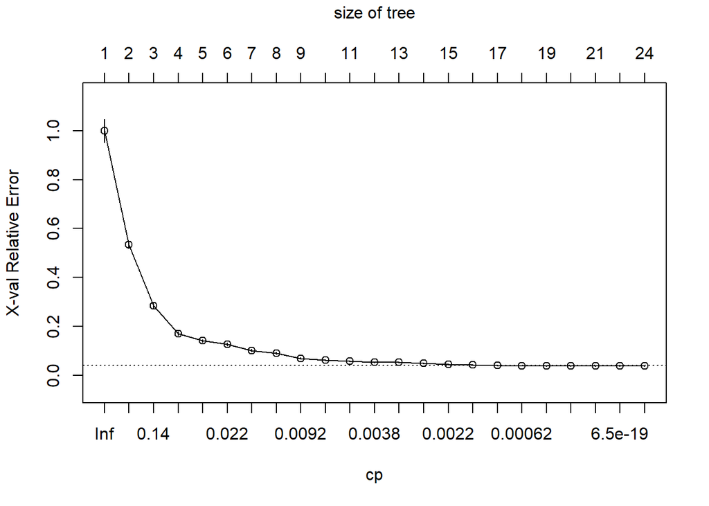

```r
plotcp(tree.model)
```

Best and Minimum CP Pruned Regression Trees:

Focus on Usage Patterns: Both trees heavily use features related to the frequency and duration of customer interactions, such as ‘Frequency_of_SMS_stan’ and ‘Seconds_of_Use_stan.’ These are strong indicators, as decreased engagement is often a precursor to churn.

CP Value and Overfitting: With a CP of 5e-04, the pruned tree avoids overfitting by removing less significant splits. This means the model will likely generalize better to new customers.

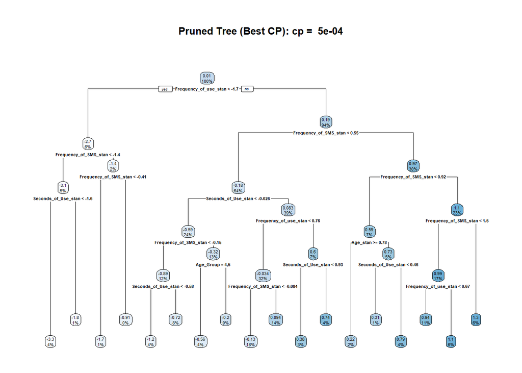

```r
cp.table <- tree.model$cptable

## Identify the minimum `xerror` and its `cp`.
min.xerror <- min(cp.table[, "xerror"])
min.cp.row <- which.min(cp.table[, "xerror"])
min.cp <- cp.table[min.cp.row, "CP"]

## Get the standard error (`xstd`) of the minimum `xerror`
xerror.std <- cp.table[min.cp.row, "xstd"]
threshold <- min.xerror + xerror.std  # Upper bound (1 SE rule)

## Find the simplest tree (`cp`) Where `xerror less than or equal to Threshold`.
best.cp.row <- which(cp.table[, "xerror"] <= threshold)[1]  # First row meeting criteria
best.cp <- cp.table[best.cp.row, "CP"]

## Two different trees: best CP vs minimum CP
pruned.tree.best.cp <- prune(tree.model, cp = best.cp)
pruned.tree.min.cp <- prune(tree.model, cp = min.cp)

# Visualize the pruned tree: best CP
rpart.plot(pruned.tree.best.cp, main = paste("Pruned Tree (Best CP): cp = ", round(best.cp,4)))
```

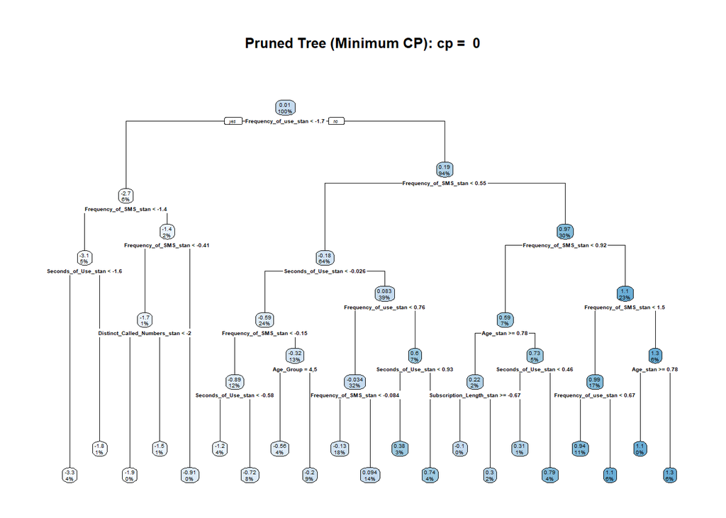

```r
# Visualize the pruned tree: minimum CP
rpart.plot(pruned.tree.min.cp, main = paste("Pruned Tree (Minimum CP): cp = ", round(min.cp,4)))
```

**5. Prediction:**

```r
# Make predictions on test data
pred.best.cp <- predict(pruned.tree.best.cp, newdata = test.data)
pred.min.cp <- predict(pruned.tree.min.cp, newdata = test.data)


# Evaluate model performance: best.cp
mse.tree.best.cp <- mean((test.data$Customer_Value_stan - pred.best.cp)^2)
rmse.tree.best.cp <- sqrt(mse.tree.best.cp)
r.squared.tree.best.cp <- cor(test.data$Customer_Value_stan, pred.best.cp)^2
# min.cp
mse.tree.min.cp <- mean((test.data$Customer_Value_stan - pred.min.cp)^2)
rmse.tree.min.cp <- sqrt(mse.tree.min.cp)
r.squared.tree.min.cp <- cor(test.data$Customer_Value_stan, pred.min.cp)^2

##
# fit ordinary least square regression
LSE01 <- lm(Customer_Value_stan ~ Call_Failure_stan+ Frequency_of_use_stan+ Subscription_Length_stan+ Age_stan+ Seconds_of_Use_stan , data = train.data)
pred.lse01 <-  predict(LSE01, newdata = test.data)
mse.lse01 <- mean((test.data$Customer_Value_stan - pred.lse01)^2)
rmse.lse01 <- sqrt(mse.lse01)
r.squared.lse01 <- cor(test.data$Customer_Value_stan, pred.lse01)^2

##
## ordinary LSE regression model with step-wise variable selection
lse02.fit <- lm(Customer_Value_stan~.,data = train.data)
AIC.fit <- stepAIC(lse02.fit, direction="both", trace = FALSE)
pred.lse02 <- predict(AIC.fit, test.data)
mse.lse02 <- mean((test.data$Customer_Value_stan - pred.lse02)^2)    # mean square error
rmse.lse02 <- sqrt(mse.lse02)                       # root mean square error
r.squared.lse02 <- (cor(test.data$Customer_Value_stan, pred.lse02))^2 # r-squared

###
Errors <- cbind(MSE = c(mse.tree.best.cp, mse.tree.min.cp, mse.lse01, mse.lse02),
                RMSE = c(rmse.tree.best.cp, rmse.tree.min.cp, rmse.lse01, rmse.lse02),
                r.squared = c(r.squared.tree.best.cp, r.squared.tree.min.cp, r.squared.lse01, r.squared.lse02))
rownames(Errors) = c("tree.best.cp", "tree.min.cp", "lse01", "lse02")
pander(Errors)
```

|  | MSE | RMSE | r.squared |
| --- | --- | --- | --- |
| **tree.best.cp** | 0.0345 | 0.1857 | 0.9666 |
| **tree.min.cp** | 0.03416 | 0.1848 | 0.9669 |
| **lse01** | 0.2419 | 0.4918 | 0.7658 |
| **lse02** | 0.06079 | 0.2466 | 0.9413 |

**6. Variable Importance for Best CP and Minimum CP**

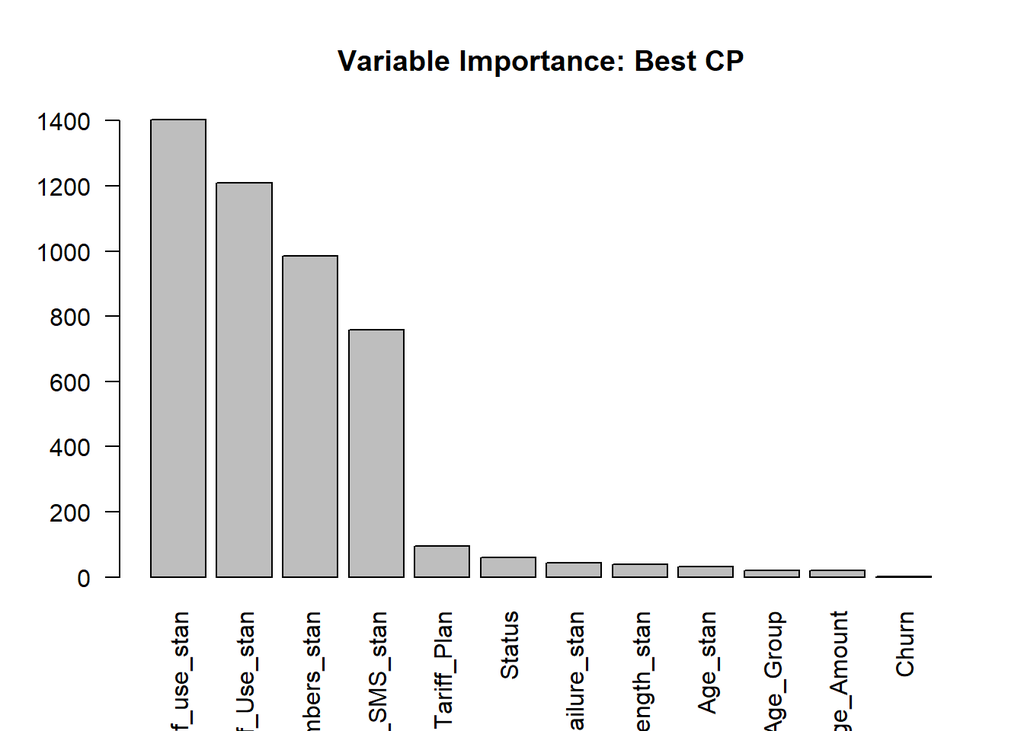

```r
# Variable importance
importance <- pruned.tree.best.cp$variable.importance
barplot(sort(importance, decreasing = TRUE),
        main = "Variable Importance: Best CP",
        las = 2)
```

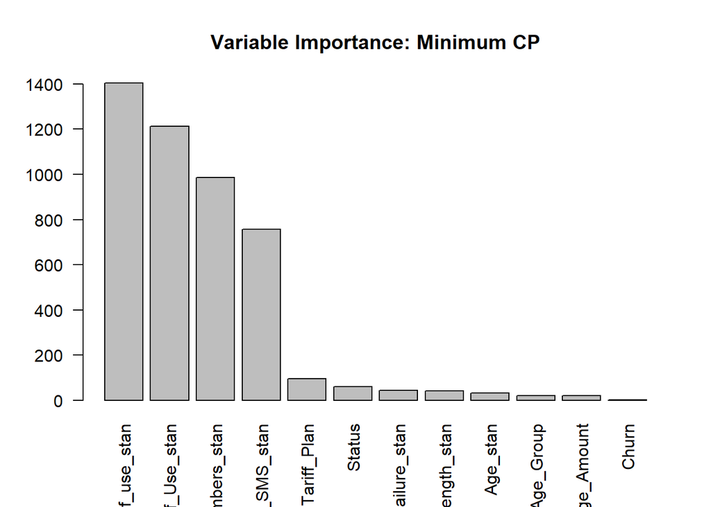

```r
# Variable importance
importance <- pruned.tree.min.cp$variable.importance
barplot(sort(importance, decreasing = TRUE),
        main = "Variable Importance: Minimum CP",
        las = 2)
```

```r
pander(summary(AIC.fit)$coef)
```

|  | Estimate | Std. Error | t value | Pr(>\|t\|) |
| --- | --- | --- | --- | --- |
| **(Intercept)** | 0.2487 | 0.02524 | 9.857 | 1.875e-22 |
| **Call_Failure_stan** | -0.06122 | 0.007921 | -7.728 | 1.649e-14 |
| **Subscription_Length_stan** | 0.04355 | 0.005325 | 8.179 | 4.819e-16 |
| **Seconds_of_Use_stan** | 0.536 | 0.01441 | 37.19 | 6.726e-235 |
| **Frequency_of_use_stan** | 0.1235 | 0.01876 | 6.583 | 5.773e-11 |
| **Frequency_of_SMS_stan** | 0.4886 | 0.006002 | 81.41 | 0 |
| **Distinct_Called_Numbers_stan** | -0.03682 | 0.01144 | -3.217 | 0.001313 |
| **Complains_stan** | 0.009664 | 0.006103 | 1.583 | 0.1135 |
| **Charge_Amount1** | -0.06515 | 0.01586 | -4.109 | 4.127e-05 |
| **Charge_Amount2** | -0.08955 | 0.01898 | -4.718 | 2.53e-06 |
| **Charge_Amount3** | -0.05622 | 0.02352 | -2.39 | 0.01691 |
| **Charge_Amount4** | -0.09224 | 0.03545 | -2.602 | 0.009331 |
| **Charge_Amount5** | -0.09664 | 0.05201 | -1.858 | 0.0633 |
| **Charge_Amount6** | 0.3966 | 0.09549 | 4.153 | 3.407e-05 |
| **Charge_Amount7** | 0.5595 | 0.07281 | 7.684 | 2.307e-14 |
| **Charge_Amount8** | 0.2959 | 0.07269 | 4.07 | 4.867e-05 |
| **Charge_Amount9** | 0.1471 | 0.08818 | 1.668 | 0.0954 |
| **Charge_Amount10** | -0.01673 | 0.09298 | -0.1799 | 0.8572 |
| **Age_Group2** | -0.09813 | 0.02653 | -3.698 | 0.0002224 |
| **Age_Group3** | -0.1123 | 0.02716 | -4.133 | 3.711e-05 |
| **Age_Group4** | -0.4158 | 0.02943 | -14.13 | 1.93e-43 |
| **Age_Group5** | -0.7928 | 0.03534 | -22.43 | 1.891e-100 |
| **Tariff_Plan2** | 0.1011 | 0.02154 | 4.691 | 2.891e-06 |
| **Status2** | -0.2213 | 0.01763 | -12.56 | 5.634e-35 |
| **Churn1** | -0.03164 | 0.01871 | -1.691 | 0.09099 |